```python
import pandas as pd
import seaborn as sns
import os
import sys
from sklearn.preprocessing import normalize
import statsmodels.api as sm
import matplotlib.patches as mpatches
import matplotlib.pyplot as plt
import matplotlib.gridspec as gridspec
import cartopy.crs as ccrs
import numpy as np
import math
from scipy import stats
```

# Sea Ice Thickness

Examining sea ice thickness via the National Snow and Ice Data Center (NSIDC) In-Situ aggregate data set.

John Baker

### Reading in the CSV

```python
## Reading in the CSV
df = pd.read_csv('G10011-aggregated-v2.csv')
df = df.drop(["Time", "Ice Freeboard", "Ice Type", "File Number"], axis=1).dropna(subset=["Latitude", "Longitude"], thresh=2)
print("This dataset has data across this many expeditions: ", len(df['Folder Name'].unique()))

## Hold reference to this aggregation
glob = df

# Separate out the single largest dataset
bigset = df[df['Folder Name'].apply(lambda x: x.endswith("Polarstern-Cruise-ARK-XVII-2001-GRE"))]

# Partition the area of interest
b_reg = df[df['Folder Name'].apply(lambda x: x.endswith("BEAU"))]
b_reg = b_reg.dropna(subset=["Ice Thickness", "EM Thick"], thresh=1)
b_reg = b_reg.sort_values(by=['Year', 'Month', 'Day'], ascending=True)
print("After filtering to the region of interest, there are these many sets left: ", len(df["Folder Name"].unique()), "\n")
print(b_reg.head(5))
```

```
This dataset has data across this many expeditions:  51
After filtering to the region of interest, there are these many sets left:  51

       Year  Month  Day  Position  Latitude  Longitude  Ice Thickness  \
65808  1950      2    7       NaN     78.03    -167.79           1.80
65809  1950      2    7       NaN     78.03    -167.79           1.50
65810  1950      2    7       NaN     78.03    -167.79           1.46
65811  1950      2    7       NaN     78.03    -167.79           1.50
65812  1950      2    7       NaN     78.03    -167.79           1.83

       Snow Thick  EM Thick                              Folder Name
65808        0.06       NaN  Soviet-Drift-Station-NP2-1950-1951-BEAU
65809        0.07       NaN  Soviet-Drift-Station-NP2-1950-1951-BEAU
65810        0.07       NaN  Soviet-Drift-Station-NP2-1950-1951-BEAU
65811        0.07       NaN  Soviet-Drift-Station-NP2-1950-1951-BEAU
65812        0.07       NaN  Soviet-Drift-Station-NP2-1950-1951-BEAU
```

### Setting Plotting Values

```python
# Get the latitude Longitude Data
lat = b_reg["Latitude"].values
lon = b_reg["Longitude"].values

# Set colors
years = b_reg["Year"].values

color_dict = {'k':'< 1960', 'g':'< 1970', 'b': '< 1980', 'y':'< 1990', 'r':'< 2000', 'm':'< 2010', 'w':'< 2020'}

col = np.where(years<1960,'k',
               np.where(years<1970,'g',
                np.where(years<1980, 'b',
                np.where(years<1990, 'y',
                np.where(years<2000, 'r',
                np.where(years<2010, 'm', 'w'))))))
```

### Plotting data

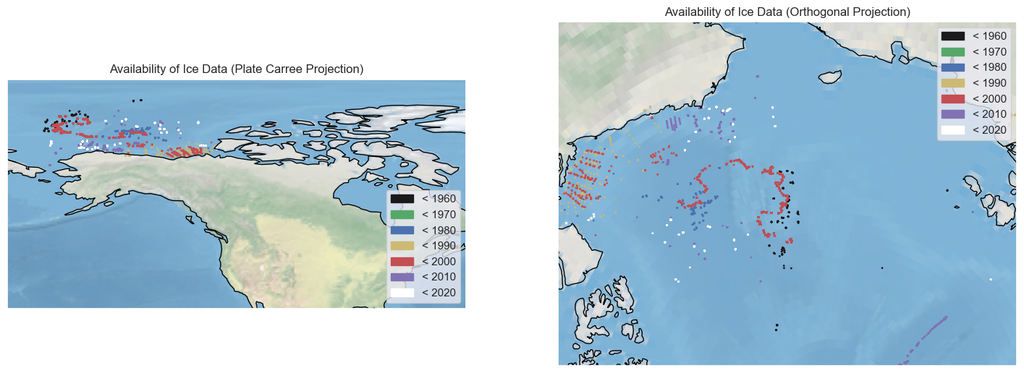

```python
original_system = ccrs.PlateCarree()
projected_coords = ccrs.Orthographic(central_longitude=0, central_latitude=90, globe=None)

fig = plt.figure(figsize=(18, 18))
gs = fig.add_gridspec(1,2)

legend_patch = []
for key in color_dict:
    legend_patch.append(mpatches.Patch(label=color_dict.get(key), color=key))


ax1 = fig.add_subplot(gs[0,0], projection=original_system)
ax1.set_extent([-180,-60,90,30], crs=original_system)
ax1.stock_img()
ax1.coastlines()
ax1.scatter(lon,lat,transform=original_system, c=col, s=1)
ax1.title.set_text('Availability of Ice Data (Plate Carree Projection)')
plt.legend(handles=legend_patch, loc ="lower right")


ax2 = fig.add_subplot(gs[0,1], projection=projected_coords)

x, y, _ = projected_coords.transform_points(original_system, lon, lat).T

# Add attributes to the plot
ax2.set_extent([min(x),max(x),min(y),max(y)], crs=projected_coords)
ax2.coastlines()
ax2.scatter(x, y, transform=projected_coords, c=col, s=1)
ax2.stock_img()
ax2.title.set_text('Availability of Ice Data (Orthogonal Projection)')

plt.legend(handles=legend_patch, loc ="upper right")
plt.show()
```

### Visualising a Large Dataset

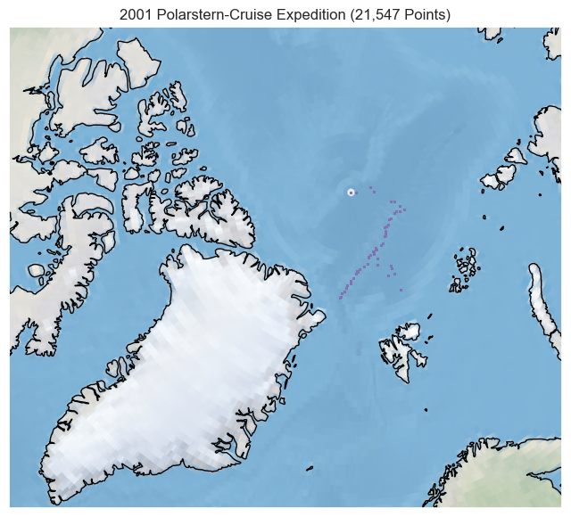

```python
lat_big = bigset["Latitude"].values
lon_big = bigset["Longitude"].values

original_system = ccrs.PlateCarree()
projected_coords = ccrs.Orthographic(central_longitude=0, central_latitude=90, globe=None)
fig = plt.figure(figsize=(8, 8))
ax = plt.axes(projection=projected_coords)

x, y, _ = projected_coords.transform_points(original_system, lon_big, lat_big).T

# Add attributes to the plot
ax.set_extent([min(x)*30,max(x)*4,min(y)*3,max(y)*30], crs=projected_coords)
ax.coastlines()
ax.scatter(x, y, transform=projected_coords, c='m', s=1)
ax.stock_img()
ax.title.set_text('2001 Polarstern-Cruise Expedition (21,547 Points)')

plt.show()
```

```python
# Setting Dataframes
imputed = bigset.dropna(axis=1, how='all') # Consider resetting index
bigset = bigset.dropna(subset=['Ice Thickness', 'EM Thick']).dropna(axis=1, how='all')

# Setting different theme
sns.set_theme()
```

### Linear Regression

```
EM Thickness Readings are easier to take than measurements from an Auger.
This dataset contains 469 manual readings, and 21539 EM readings.
Thus, we want to examine how much we can trust those measurements by exploring the relationship between them.

y = 0.92x + 0.18
Adjusted R^2 Value: 0.8659843457694136
P Value: 2.313840006273919e-202
The adjusted R^2 Value and low P value demonstrate there is a high correlation between these variables, and our model captures a significant portion of the variance.
```

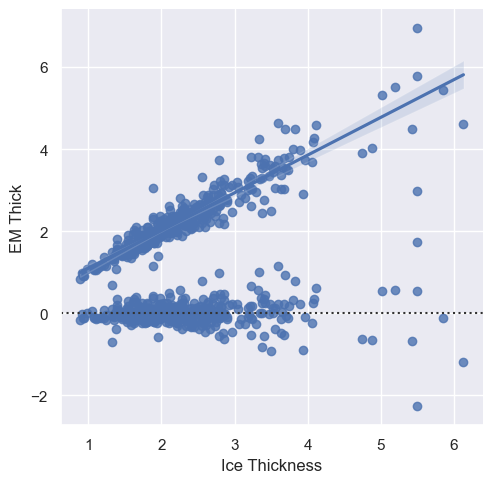

```python
counts = imputed.count()
print("EM Thickness Readings are easier to take than measurements from an Auger.")
print("This dataset contains", counts["Ice Thickness"], "manual readings, and", counts["EM Thick"], "EM readings.")
print("Thus, we want to examine how much we can trust those measurements by exploring the relationship between them.\n")

# Plot the relationship between Ice Thickness and EM Thickness
lr = sns.lmplot(data=bigset, x="Ice Thickness", y="EM Thick")
rsd = sns.residplot(data=bigset, x="Ice Thickness", y="EM Thick")

# Calculate model fit
slope, intercept, r_value, p_value, _ = stats.linregress(bigset['Ice Thickness'].values,bigset['EM Thick'].values)
equation = "y = " + '{0:.2f}'.format(slope) + "x + " + '{0:.2f}'.format(intercept)
num_samples = len(bigset['Ice Thickness'].values)
num_inpdt_var = 1
adj_r2 = 1-(1-(r_value**2)*(num_samples-1)/(num_samples-num_inpdt_var-1))
print(equation)
print("Adjusted R^2 Value:", adj_r2)
print("P Value:", p_value)
print("The adjusted R^2 Value and low P value demonstrate there is a high correlation between these variables, and our model captures a significant portion of the variance.")

def em_to_ice_thick(x):
    return slope * x + intercept
```

### Imputing Model Values

```python
# Imputing
imputed['isTruth'] = imputed['Ice Thickness'].apply(lambda x: False if math.isnan(float(x)) else True)

for index, row in imputed.iterrows():
    if not row.isTruth:
        data = row['EM Thick']
        res = em_to_ice_thick(data)
        imputed.at[index, 'Ice Thickness'] = res

imputed['deltaThick'] = imputed['EM Thick'] - imputed['EM Thick'].shift(-1)
dfg = imputed.groupby(by=["Latitude", "Longitude"])
track1 = dfg.get_group((84.667, 5.1))
```

### Plotting Thickness Track

```
Normalized Standard Deviation:  0.1409347955269019
Normalized Test p-value = 3.56337e-34
The null hypothesis can be rejected
```

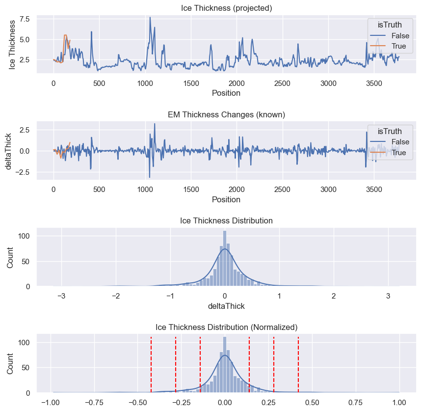

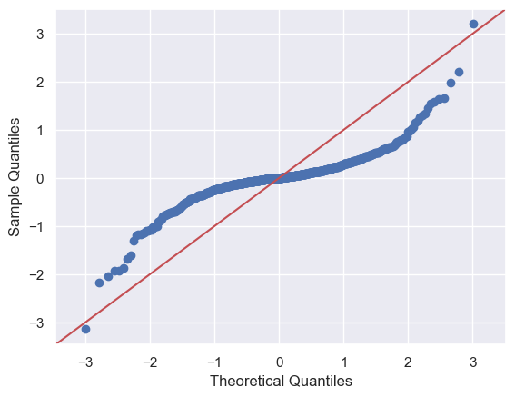

```python
# Plotting the simulated sea ice thickness
fig, axes = plt.subplots(4, 1, figsize=(10, 10))
plt.subplots_adjust(hspace=0.8)
ax1 = sns.lineplot(data=track1, x="Position", y="Ice Thickness", hue="isTruth", ax=axes[0]).set_title('Ice Thickness (projected)')
ax2 = sns.lineplot(data=track1, x="Position", y="deltaThick", hue="isTruth", ax=axes[1]).set_title('EM Thickness Changes (known)')
ax3 = sns.histplot(data=track1, x="deltaThick", ax=axes[2], kde=True).set_title('Ice Thickness Distribution')

norm_data = normalize([track1.deltaThick], norm="max").flatten()
st_dev = np.std(norm_data)

ax4 = sns.histplot(data=norm_data, ax=axes[3], kde=True).set_title('Ice Thickness Distribution (Normalized)')
plt.vlines(x=[st_dev * -3, st_dev  *-2, st_dev * -1, st_dev, st_dev * 2, st_dev * 3], ymin=0, ymax=110, color='red', linestyles='dashed')
print("Normalized Standard Deviation: ", st_dev)
k2, p = stats.normaltest(track1.deltaThick)
alpha = 1e-3
sm.qqplot(track1.deltaThick, line='45')

print("Normalized Test p-value = {:g}".format(p))
if p < alpha:  # null hypothesis: x comes from a normal distribution
    print("The null hypothesis can be rejected")
else:
    print("The null hypothesis cannot be rejected")
plt.show()
```

### Examining Other Tracks in the Large Dataset...

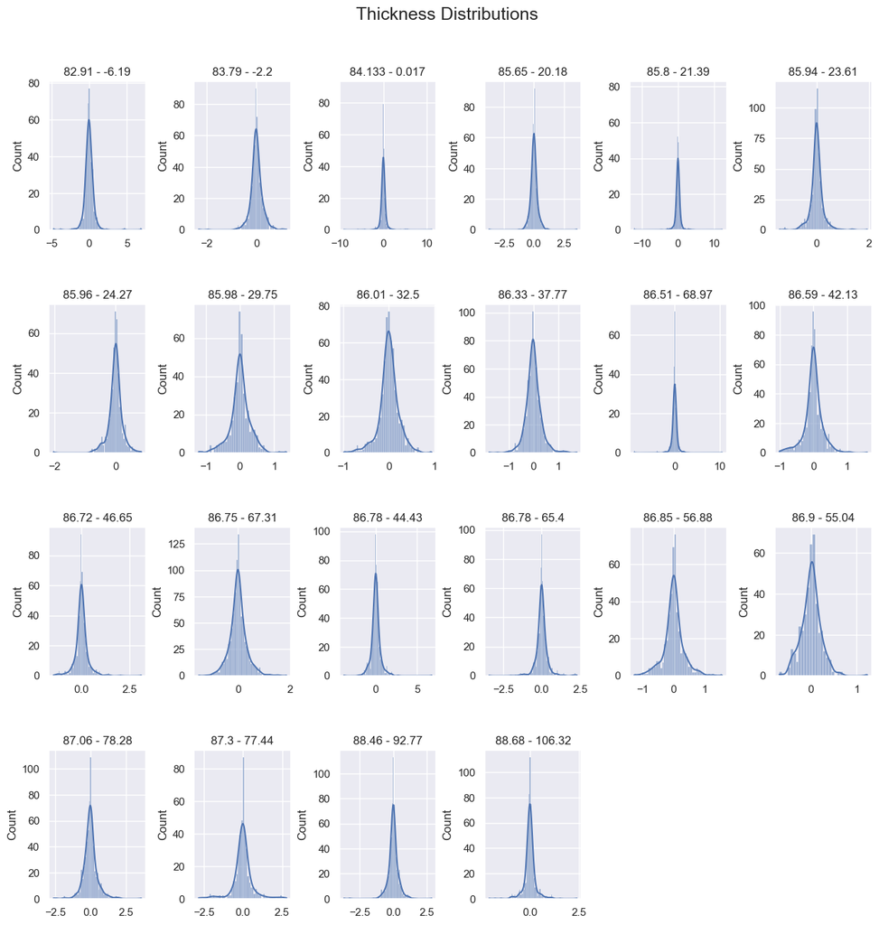

```python
# Plotting the ice thickness distribution for the remaining tracks
dfg.groups.pop((84.667, 5.1), None)
short_tracks = []
for key in dfg.groups.keys():
    if len(dfg.groups.get(key)) < 400:
        short_tracks.append(key)

for key in short_tracks:
    dfg.groups.pop(key, None)

plt.figure(figsize=(15, 15))
plt.subplots_adjust(hspace=0.5, wspace=0.5)
plt.suptitle("Thickness Distributions", fontsize=18, y=0.95)

# loop through the length of tickers and keep track of index
for n, coords in enumerate(dfg.groups):
    track = dfg.get_group(coords)
    # add a new subplot iteratively
    ax = plt.subplot(4, 6, n + 1)


    # filter df and plot ticker on the new subplot axis
    sns.histplot(data=track, x="deltaThick", kde=True)

    # chart formatting
    ax.set_title(track['Latitude'].iloc[0].astype(str) + " - " +  track['Longitude'].iloc[0].astype(str))
    ax.set_xlabel("")
```

### Aggregate Distribution (In Progress)

```python
# Print the distribution of ALL data points.
set_len = []
glob_groups = glob.groupby(by=["Folder Name"])
print(len(glob_groups.groups.keys()))

for key in glob_groups.groups.keys():
    set_len.append(len(glob_groups.groups.get(key).values))

print(np.mean(set_len))
```

```
51
1348.0196078431372
```

# Final Remarks / Conclusion

A few conclusions can be made from this exploratory data analysis:

- There is a strong relationship between manual measurements of ice thickness and EM measurements of ice thickness.
  - This relationship falls off as ice thickness increases, but that is a limitation of this data source
- Not every track follows a normal distribution, but longer length tracks tend to look like they do.
  - This makes some sense, as some sections of ice may have irregularly jagged or smooth underwater surfaces leading to a skewed distribution. As the set captures more data it makes sense that the distribution looks more normal.
  - It's apparent through the normalized test and Q-Q Chart that even the longest track that *looks* normally distributed, isn't.
  - The Q-Q chart suggests that the data set includes too much data in the extremities.
  - As it stands, further statistical analysis will need to follow non-parametric methods because of the non-normal distribution. It may be possible to adjust the data / scale to make the data more normal though.
  - More investigation needs to be done to find whether these relationships hold for temporally and spatially different ice regions.

It's important to notice that this exact analysis concerns the physical ice thickness. From the charts above, it's possible to visualize the cross-section of the ice sheet by plotting along-track ice depth but the axis will need to be inverted to represent depth going in the downwards direction. It's also important to notice that the distributions plotted were of the *change* in ice thickness per unit of measurement, not of direct ice thickness.

Ideally, the general relationships of ice thickness will be applied to other remote sensing methods (such as ICESat-2's ATLAS) to get a better understanding of what the sea ice could look like. If further investigation were to prove a similar distribution of ice thickness (in spatially and temporally different regions), it would be reasonable to preprocess data from ICESat-2 to more closely resemble that pattern.

At the moment, I'm concerned with modeling the freeboard height measurements of ice by correlating SAR imaging with ICESat-2's laser altimeter. Until the European Space Agency (ESA) approves of my project proposal and allows access to ICEYE's high-resolution SPOT imaging, research will need to be done to prepare other data sources for correlation. Though this specific analysis concerns sea ice thickness and not freeboard depth, I hope the insight becomes more valuable as the project continues.

Below is an attached chart of laser altimetry measurements taken from ICESat-2 which I hope to find a viable preprocessing method for.

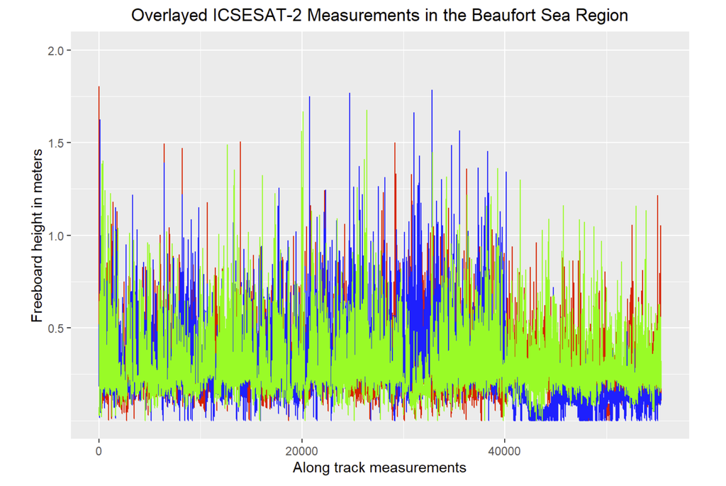